# Beta Regression

Team Bee (Beta Regressionists) (Advisor: Dr. Seals)

Anaite Montes Bu, Travis Keep

## Introduction

- Regression analysis is a statistical tool used to explore relationships between variables.
- Beta Regression: When the dependent variable is a ratio or percentage.

## Shortfalls of Normal Regression

- Assumes dependent variable is normally distributed
- Assumes variance is constant throughout

Generally not true with ratios or percentages

## When dependent variable lies in (0, 1)

- True of ratios or percents such as test scores
- Variance typically less near the extremes e.g 0 or 1.

## Reading Skills data set

- Reading skills based on IQ and if student has dyslexia N=44
- Normal regression shows IQ alone not significant in predicting reading score
- Beta regression shows IQ alone is significant in predicting reading score [1]

## Beta distribution

The PDF of random variable with a beta distribution is as follows.

$$f(y) = \begin{cases}
\frac{y^{\alpha-1}(1-y)^{\beta-1}}{B(\alpha,\beta)}, & 0 \le y \le 1 \\
0, & \text{elsewhere}
\end{cases}$$
Where $B(\alpha,\beta) = \int_0^1 y^{\alpha-1}(1-y)^{\beta-1} \ dy = \frac{\Gamma(\alpha) \Gamma(\beta)}{\Gamma(\alpha+\beta)}.$

$\alpha$ and $\beta$ are the shape variables where $\alpha > 0 \quad \beta > 0$. [2]

## Beta Distribution Mean and Variance

$$E[Y] = \mu = \frac{\alpha}{\alpha+\beta} \ \ \ \text{and} \ \ \ V[Y] = \sigma^2 = \frac{\alpha\beta}{(\alpha+\beta)^2(\alpha+\beta+1)}$$
[2]

## Introduction of $\mu$ and $\phi$

For beta regression, it is useful to introduce the following

$$\mu = \frac{\alpha}{\alpha+\beta} \\
\phi = \alpha + \beta$$
$\mu$ is the mean of the beta regression while the higher the $\phi$ the less the variance or the less spread out the PDF function is. [3]

## Revised Beta Distribution

$$f(y; \mu, \phi) = \frac{\Gamma(\phi)}{\Gamma(\mu \phi) \Gamma((1 - \mu)\phi)} y^{\mu\phi - 1}(1 - y)^{(1 - \mu)\phi - 1}, \quad 0 < y < 1$$
Where:
- **(μ)** is the mean, **(ϕ)** is the precision (inverse of the variance), **(Γ)** is the gamma function.

## Beta Distribution Variance

$$\text{Var}(Y) = \frac{\mu(1 - \mu)}{1 + \phi}$$
When $\mu$ is near the extremes, 0 or 1, variance drops. [4]

## Extended Beta Regression

**Bias** **Correction/Reduction** - **Type** **of** **Estimator:**

- ML (Maximum Likelihood): Standard method, useful but may yield biased estimates in certain conditions.[5]
- BC (Bias-Corrected): Adjusts estimates to correct for bias, providing more reliable parameter values.
- BR (Bias-Reduced): Shrinks estimates towards a central value, which can improve predictive performance.

## **Bias** **Correction/Reduction**

```
Call:
betareg(formula = m1, data = suicide_dataset, type = "BC")

Quantile residuals:
    Min      1Q  Median      3Q     Max
-4.5019 -0.5515 -0.0544  0.4490  6.5013

Coefficients (mean model with logit link):
                            Estimate Std. Error z value Pr(>|z|)
(Intercept)               -5.490e+00  1.530e-01 -35.872  < 2e-16 ***
HDI_year                   3.308e+00  2.030e-01  16.297  < 2e-16 ***
GDP_capita                -8.702e-06  7.265e-07 -11.978  < 2e-16 ***
sexmale                    8.151e-01  1.847e-02  44.125  < 2e-16 ***
age25-34 years             8.994e-02  3.226e-02   2.787  0.00531 **
age35-54 years             8.603e-02  3.967e-02   2.169  0.03010 *
age5-14 years             -9.579e-01  4.562e-02 -20.998  < 2e-16 ***
age55-74 years            -1.345e-01  5.281e-02  -2.546  0.01090 *
age75+ years              -1.821e-01  5.994e-02  -3.038  0.00238 **
generationG.I. Generation  4.913e-01  4.812e-02  10.208  < 2e-16 ***
generationGeneration X    -2.116e-01  3.688e-02  -5.738  9.6e-09 ***
generationGeneration Z    -5.561e-01  6.738e-02  -8.253  < 2e-16 ***
generationMillenials      -4.287e-01  4.574e-02  -9.372  < 2e-16 ***
generationSilent           9.104e-02  3.668e-02   2.482  0.01308 *

Phi coefficients (precision model with log link):
             Estimate Std. Error z value Pr(>|z|)
(Intercept) 2.149e+00  2.078e-01  10.344  < 2e-16 ***
HDI_year    6.433e-01  2.881e-01   2.233   0.0255 *
GDP_capita  8.314e-06  1.150e-06   7.232 4.75e-13 ***
---
Signif. codes:  0 '***' 0.001 '**' 0.01 '*' 0.05 '.' 0.1 ' ' 1

Type of estimator: BC (bias-corrected)
Log-likelihood: 1.917e+04 on 17 Df
Pseudo R-squared: 0.4625
Number of iterations: 33 (BFGS) + 2 (Fisher scoring)
```

## Beta Regression Trees

- This extension uses recursive partitioning to model data that might exhibit subgroup-specific relationships.
- It builds decision trees by splitting data into different subgroups based on the instability of model parameters across partitioning variables.

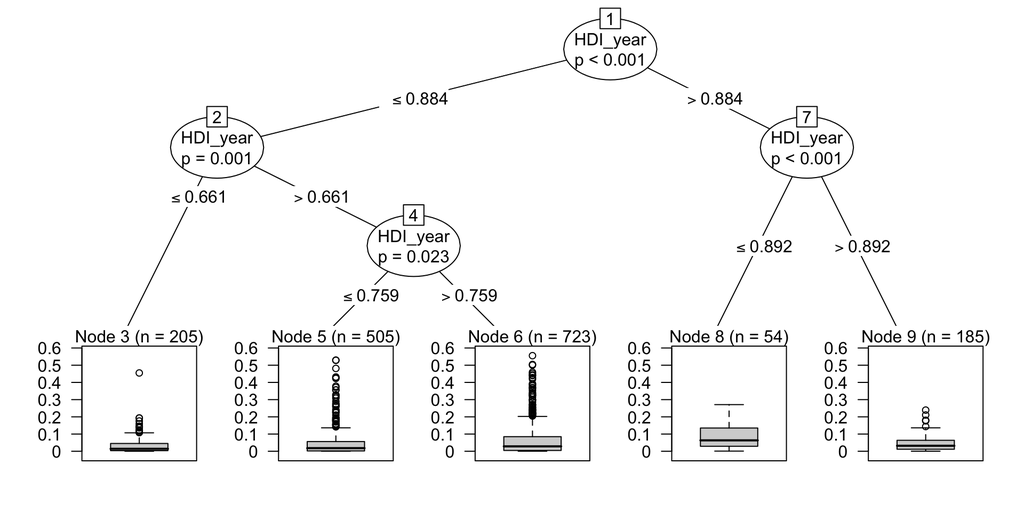

## Diagnostic Plots

The package **betareg** allows users to perform both fixed and variable dispersion beta regression. The model is based on the beta distribution, using a parameterization with the mean and precision[6].

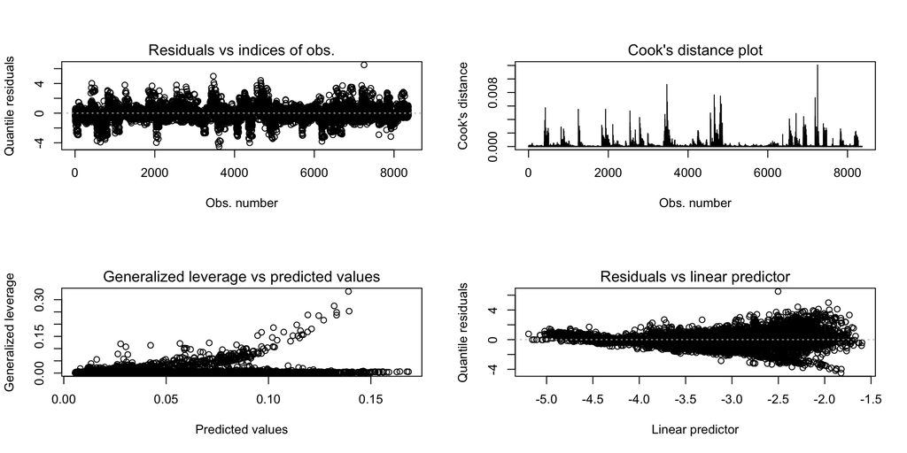

## Conclusion

- Effective for proportion data, Ideal for modeling data bounded in the (0, 1) range.
- Models both mean and precision, managing boundary cases and latent heterogeneity.
- Bias correction and beta regression trees expand its capabilities.
- The betareg package in R offers a powerful, flexible framework for analysts.

## References

[1]

M. Smithson and J. Verkuilen, “A better lemon squeezer? Maximum-likelihood regression with beta-distributed dependent variables,” *Psychol. Methods*, vol. 11, no. 1, pp. 54–71, Mar. 2006, doi: 10.1037/1082-989X.11.1.54.

[2]

D. D. Wackerly, *Mathematical statistics with applications*, 6th ed. Duxbury Press, 2002.

[3]

S. Ferrari and F. Cribari-Neto, “Beta regression for modelling rates and proportions,” *J. Appl. Stat.*, vol. 31, no. 7, pp. 799–815, Aug. 2004, doi: 10.1080/0266476042000214501.

[4]

S. Ferrari and F. Cribari-Neto, “Beta regression for modelling rates and proportions,” *J. Appl. Stat.*, vol. 31, no. 7, pp. 799–815, Aug. 2004.

[5]

B. Grün, I. Kosmidis, and A. Zeileis, “Extended beta regression inR: Shaken, stirred, mixed, and partitioned,” *J. Stat. Softw.*, vol. 48, no. 11, 2012.

[6]

A. Zeileis, F. Cribari-Neto, B. Grün, and I. Kosmidis, “Betareg: Beta regression.” The R Foundation, Apr. 2004.